# Coding Lab 4: Data Visualization

Now we have to tell R what type of plot we want to make. Let’s start with a scatter plot. We do this by adding a `+` and then the command `geom_point()` on the next line.

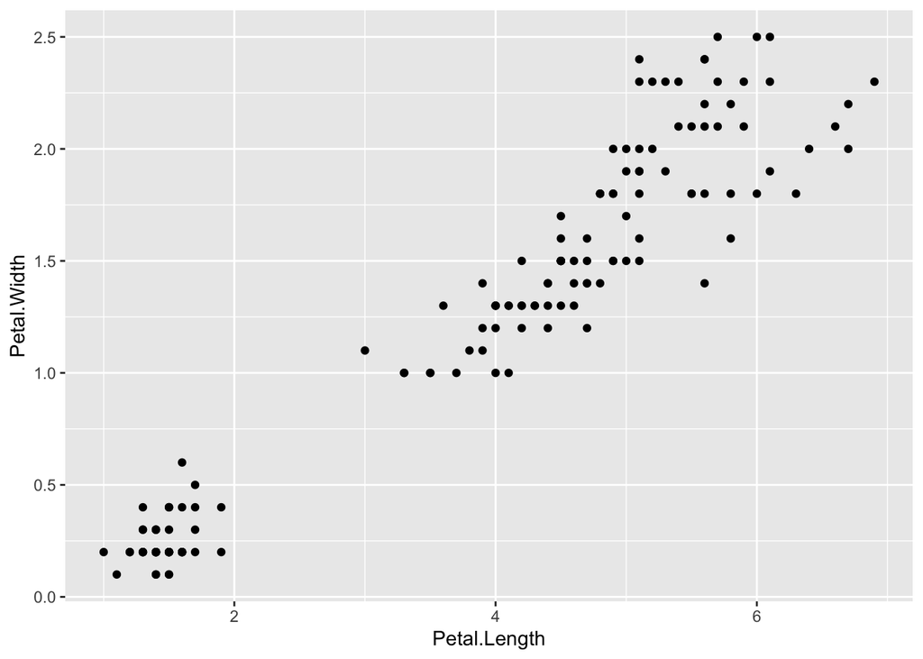

```r
ggplot(aes(x = Petal.Length, y = Petal.Width), data = iris) +
  geom_point()
```

- note that there are two ways to do this, you could write code like I have above, or you could put your X and Y and aes() command in the geom_point() function.

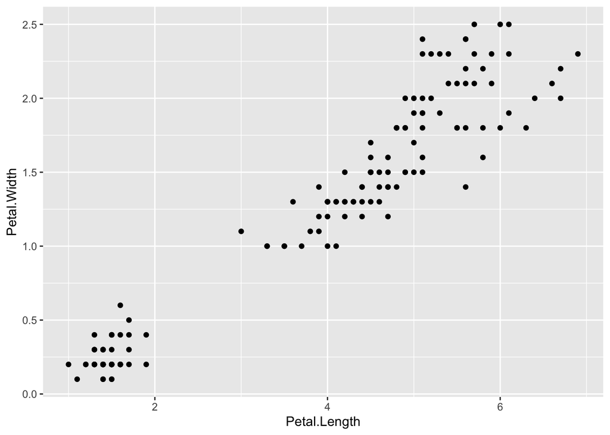

```r
ggplot(data=iris)+
  geom_point(mapping=aes(x=Petal.Length,y=Petal.Width))
```

You can also add multiple `geoms` to your plot, for example it might be useful if we had a line that showed the general relationship between Petal Length and Petal Width

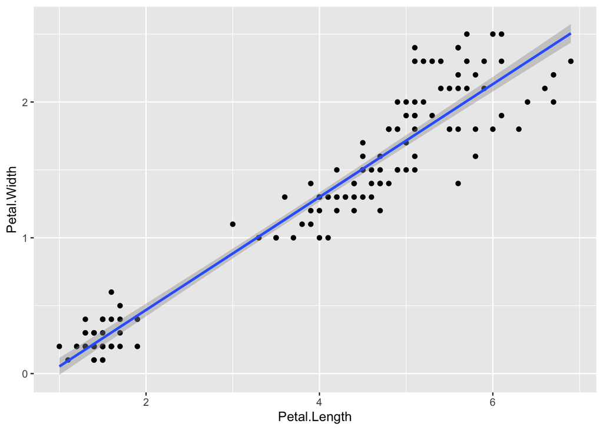

```r
ggplot(aes(x = Petal.Length, y = Petal.Width), data = iris) +
  geom_point() +
  geom_smooth(method = 'lm')
```

You can also add color to your plots in order to get more information about your data, for example what if we wanted to visualize the relationship between petal length and petal width by the species of flower?

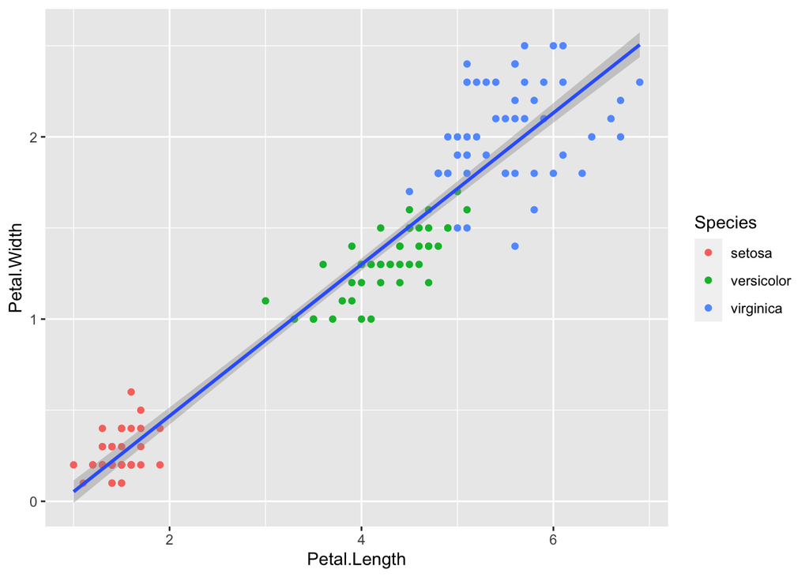

```r
ggplot(aes(x = Petal.Length, y = Petal.Width), data = iris) +
  geom_point(aes(color = Species)) +
  geom_smooth(method = 'lm')
```

Note, if you put `color = Species` in the ggplot aes() function, you will change the color of all of the later `geom` arguments as well, not just the color of `geom_point`

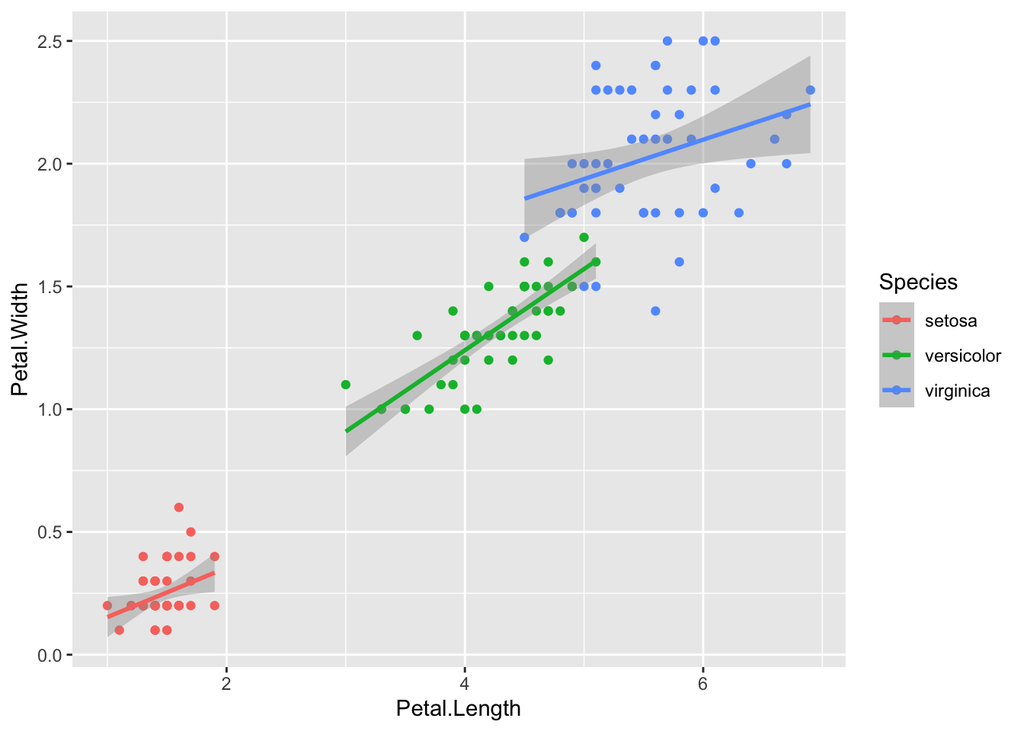

```r
ggplot(aes(x = Petal.Length, y = Petal.Width, color = Species), data = iris) +
  geom_point() +
  geom_smooth(method = 'lm')
```

One of the most important considerations when creating visualizations is making sure that they are understandable. One of the easiest ways to do this is to add labels. In `ggplot` you can do this by using `ggtitle` `xlab` and `ylab`

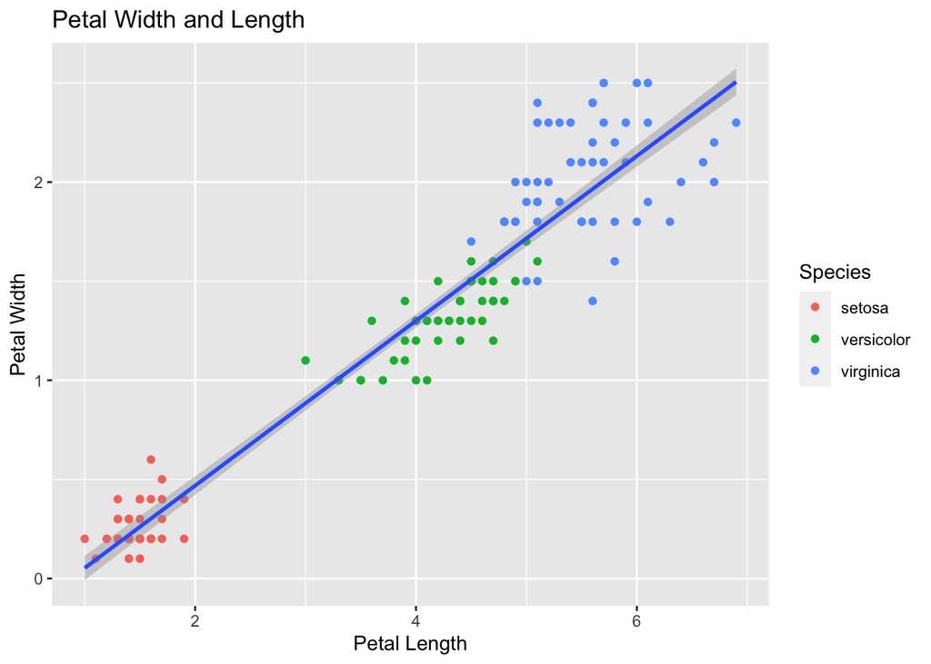

```r
ggplot(aes(x = Petal.Length, y = Petal.Width), data = iris) +
  geom_point(aes(color = Species)) +
  geom_smooth(method = 'lm') +
  ggtitle("Petal Width and Length") +
  ylab("Petal Width") +
  xlab("Petal Length")
```

R can make many different types of plots! Let’s try a few more.

### Bar Plots

When you have a single categorical variable you can make a bar plot using `geom_bar`. `geom_bar` will count the number of instances of different categories and plot them for you. This plot is best used if you are running a test like chi-squared goodness of fit.

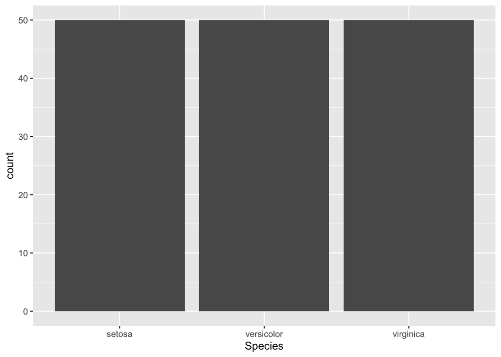

```r
ggplot(aes(x = Species), data = iris) +
  geom_bar()
```

### Histograms

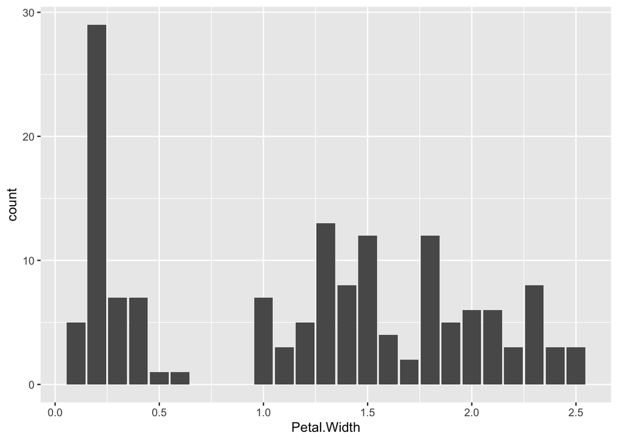

```r
ggplot(aes(x = Petal.Width), data = iris) +
  geom_bar()
```

### Frequency Plot

Another way to visualize the distribution of your data is through `geom_freqpoly`.

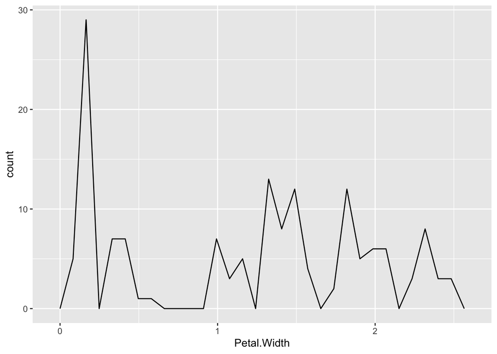

```r
ggplot(aes(x = Petal.Width), data = iris) +
  geom_freqpoly()
```

### Column Plot

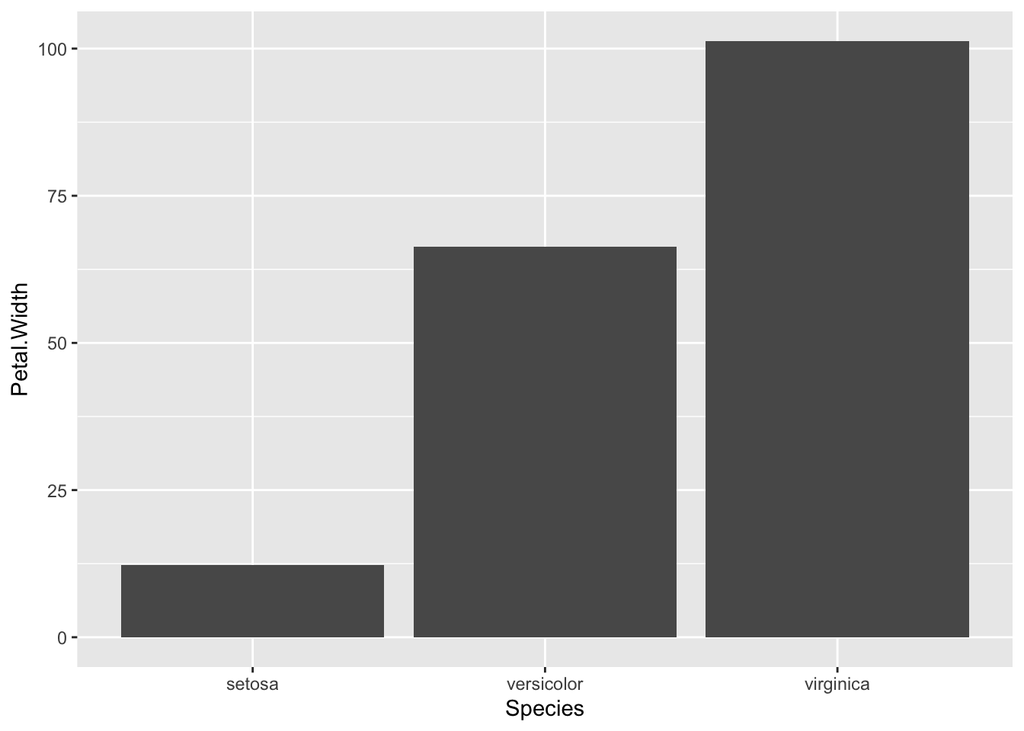

```r
ggplot(aes(x = Species, y = Petal.Width), data = iris) +
  geom_col()
```

Now, the Y axis here is just the sum of the pedal width for each flower species. However, this data is not necessarily useful. To get useful information, such as the differences between the average pedal width, we need to group our data first:

```r
average_width <- iris %>%
  group_by(Species) %>%
  summarize(average = mean(Petal.Width, na.rm = TRUE))

average_width
```

```
## # A tibble: 3 × 2
##   Species    average
##   <fct>        <dbl>
## 1 setosa       0.246
## 2 versicolor   1.33
## 3 virginica    2.03
```

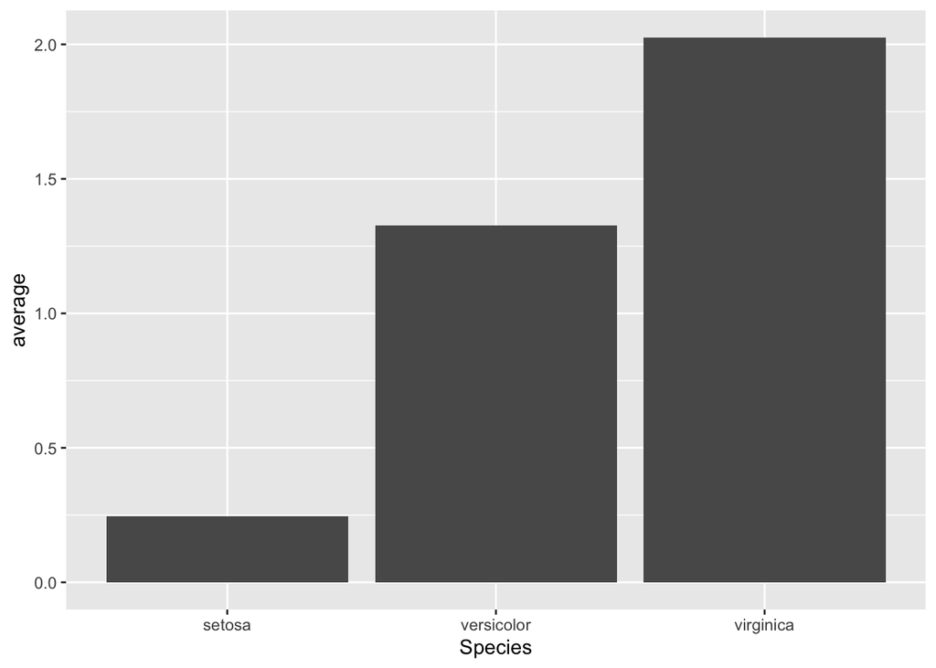

```r
ggplot(aes(x = Species, y = average), data = average_width) +
  geom_col()
```

For more information about the different types of plots you can create using ggplot, see: https://www.maths.usyd.edu.au/u/UG/SM/STAT3022/r/current/Misc/data-visualization-2.1.pdf

### **Practice Questions**

For the following practice questions, you will be using the dataset `mtcars`. More information about `mtcars` can be found here: https://www.rdocumentation.org/packages/datasets/versions/3.6.2/topics/mtcars

```r
data("mtcars")
```

Before we begin our analysis, I am going to tell R to treat the variable `cyl` as a categorical variable. The way to do this is to use the `as_factor` function, and then override the original variable.

```r
mtcars$cyl <- as_factor(mtcars$cyl)
```

#### Question 1a

Using `geom_point` create a plot with `mpg` on the Y axis and `wt` on the X axis

#### Question 1b

Now color the points according to `cyl`

#### Question 1c

Now use `geom_smooth(method = 'lm')` to add a regression line to the plot.

#### Question 1d

Finally, add labels to the plot to make it easier to read.

#### Question 1e

Finally, write a brief sentence interpreting the results of your plot.

#### Question 2

Use `geom_bar` to create a bar plot of `cyl`

#### Question 3a

Create a new variable titled `average_qsec` that calculates the average quarter mile time (`qsec`) by the number of cylinders (`cyl`)

#### Question 3b

Now plot the average quarter mile time by the number of cylinders using `geom_col()`

#### Question 3c

Write a sentence to interpret the results of this plot.